# Projeto Final

Luiz Antônio

13/10/2020

# Projeto Final - Netflix Movies and TV Shows

## Introdução

Atualmente, as plataformas de streaming são um percentual importante das atividades de lazer de um individuo. Existindo inúmeras plataformas, o público se divide em escolher apenas uma ou manter mais, pois, cada uma oferece alguns aspectos que se sobressaem.

O Conjunto de dados utilizado neste projeto contém informações sobre os conteúdos disponíveis no catálogo Netflix, categorizados como “Movie” e “Tv Show”. Com as informações disponíveis do DataSet, pretendo quantificar e classificar alguns dos aspectos que atraem o público e verificar se a plataforma Netflix os satisfazem.

Classificados em:  
1. Ótimo  
2. Bom  
3. Razoável  
4. Ruim  
5. Péssimo

## Pacotes Requeridos

Para o projeto, todos os pacotes escolhidos são para organizar e manipular os dados.

```r
library("stringr") #Manipulação de Texto (String)
library("dplyr") #Manipulação e Transformação de Dados
library("tidyr") #Formatar/Formalizar os Dados
library("tm") #Mineração de Texto
library("wordcloud") #Criação de Nuvem de Palavras
```

## Preparação dos Dados

Neste projeto, utilizei de dados abertos da plataforma Kaggle. Dados estes que foram coletados através da Fixable(Um mecanismo de busca Netflix de terceiros). O conjunto de dados consiste em programas de TV e filmes disponíveis na netflix que foram adicionados no período de 2008 a 2020.

Com posse do dataset, no meio diretório, obtido pelo link: [DataSet](https://www.kaggle.com/shivamb/netflix-shows/download) Utilizo o comando

```r
netflix <- read.csv("netflix_titles.csv", header = T,strip.white = T, na.strings = "", quote = "\"", sep = ",")
```

para importar o dataset.

Em seguida, utilizo o comando

```r
str(netflix)
```

para visualizar a estrutura do DataFrame.

Nisto percebo que se trata de um DataFrame com 6234 linhas e 12 colunas. Noto que algumas alterações possam ser feitas para melhorar minha visualização. Para prosseguir, irei anular algumas colunas que serão inúteis para o andamento do projeto. Colunas a serem retiradas : show_id e rating.

```r
netflix <- netflix[-c(1,9)]
```

Outras alterações a serem feitas são: Transformar a coluna “type” em um Fator, alterar a coluna “date_added” para apenas o ano de adesão dos filmes/programas de Tv a plataforma e deixar os anos do dataframe em tipo numérico.

```r
#Transformando "type" em fator
netflix$type <- as.factor(netflix$type)

#Alterando "date_added"
netflix <- netflix %>% separate(col = "date_added", into = c("month_added", "year_added"), sep = ",", fill = "right")
netflix <- netflix[-6]
#Deixando "year_added" e "release_year" em Numerico
netflix$year_added <- as.numeric(netflix$year_added)
netflix$release_year <- as.numeric(netflix$release_year)
```

Para realizar a alteração da coluna “date_added”, separo-a em duas colunas resultantes “month_added” e “year_added” e depois removo a coluna “month_added” pois, será inutilizada no decorrer do projeto.

Por último, verifico a existência de linhas duplicadas.

```r
which(duplicated(netflix))
```

```
## [1] 2125
```

Com o resultado, confirmo a existência de uma linha duplicada e a removo.

```r
netflix <- netflix[-2125,]
```

Depois da preparação o DataSet Resulta em:

```
## 'data.frame':    6233 obs. of  10 variables:
##  $ type        : Factor w/ 2 levels "Movie","TV Show": 1 1 2 2 1 2 1 1 2 1 ...
##  $ title       : chr  "Norm of the North: King Sized Adventure" "Jandino: Whatever it Takes" "Transformers Prime" "Transformers: Robots in Disguise" ...
##  $ director    : chr  "Richard Finn, Tim Maltby" NA NA NA ...
##  $ cast        : chr  "Alan Marriott, Andrew Toth, Brian Dobson, Cole Howard, Jennifer Cameron, Jonathan Holmes, Lee Tockar, Lisa Duru"| __truncated__ "Jandino Asporaat" "Peter Cullen, Sumalee Montano, Frank Welker, Jeffrey Combs, Kevin Michael Richardson, Tania Gunadi, Josh Keaton"| __truncated_…
##  $ country     : chr  "United States, India, South Korea, China" "United Kingdom" "United States" "United States" ...
##  $ year_added  : num  2019 2016 2018 2018 2017 ...
##  $ release_year: num  2019 2016 2013 2016 2017 ...
##  $ duration    : chr  "90 min" "94 min" "1 Season" "1 Season" ...
##  $ listed_in   : chr  "Children & Family Movies, Comedies" "Stand-Up Comedy" "Kids' TV" "Kids' TV" ...
##  $ description : chr  "Before planning an awesome wedding for his grandfather, a polar bear king must take back a stolen artifact from"| __truncated__ "Jandino Asporaat riffs on the challenges of raising kids and serenades the audience with a rousing rendition of"| __truncated__ "With the help of…
```

Um Dataframe com 6233 linhas e 10 colunas

## Analise Exploratória dos Dados

A partir de agora, irei manipular os dados do Dataframe, para cada aspecto comentado anterior, a fim de obter os resultados para verificação e analise.  
**1. Inclusão de Filmes/Tv Show Recentemente Lançados**  
Para obtenção do dado, iremos buscar a frequência do quando de tempo levou para os conteúdos ficarem disponível na plataforma.

Primeiro procuro a diferença entre a data de inclusão para a data de lançamento. Considerando a inexistência da plataforma como streaming ate 2007, limito a diferença para valores maiores-iguais a 0 e menores-iguais a 13. Obs: O resultado trazia alguns números negativos, porém, um filme não pode ser adicionado a plataforma antes de lançado.

```r
x <- netflix$year_added - netflix$release_year
x <- x[x>=0 & x<=13]
```

Obtendo esses valores, gero um gráfico que me permita melhor análise através do código.

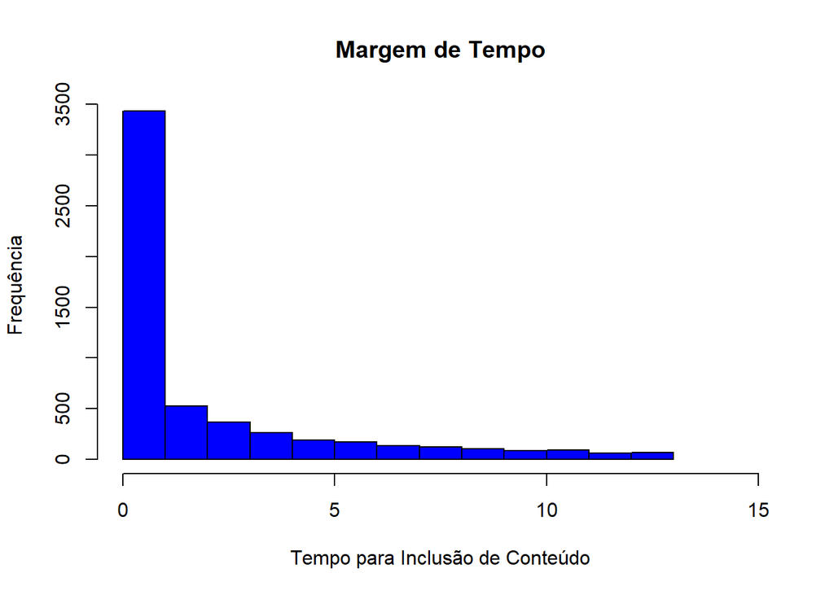

```r
hist(x, col = "blue", xlab = "Tempo para Inclusão de Conteúdo", main = "Margem de Tempo", xlim = c(0, 15), ylab = "Frequência")
```

Com isso, posso enxergar que o grande percentual de conteúdo se concentra em menos de 10 anos de diferença. Agora, tiro a média de tempo para inclusão de um conteúdo no catálogo para poder classifica-lo.

```r
mean(x,na.rm = T)
```

```
## [1] 2.294023
```

Obtendo essa média, classifico esse aspecto em **Bom**, já que devesse ser considerado o prazo de liberação da cinematografia pós-produção.

**2. Variedades de Filmes/Tv Show Disponíveis por Categoria**  
Os conteúdos se apresentam em mais de uma categoria, por isso meu primeiro passo será separar as categorias de cada conteúdo de modo a quantifica-los.

Primeiro procuro saber o máximo de categorias que um filme se encontra, para isso uso o código abaixo.

```r
max(str_count(netflix$listed_in,","))
```

```
## [1] 2
```

Após interpretar o resultado, pudesse perceber que o máximo de categorias de um filme são 3, simplesmente por que existe duas separações. Por Exemplo: ’’’ International Movies**,**Sci-Fi & Fantasy**,** Thrillers ’’’ Agora que tenho um valor de categorias posso dividi-las através do código a seguir realizo essa ação.

```r
netflix <- netflix %>% separate(col = "listed_in", into = c("category_1", "category_2", "category_3"), sep = ",", fill = "right")
```

```
##                 category_1              category_2                 category_3
## 1 Children & Family Movies                Comedies                       <NA>
## 2          Stand-Up Comedy                    <NA>                       <NA>
## 3                 Kids' TV                    <NA>                       <NA>
## 4                 Kids' TV                    <NA>                       <NA>
## 5                 Comedies                    <NA>                       <NA>
## 6           Crime TV Shows  International TV Shows  Spanish-Language TV Shows
```

Seguindo, realizo três etapas, são elas: obter um vetor com todas as categorias, transformar o vetor em fator para obter os levels e tranformar o levels em caracteres para manipulação. Durante o caminho, percebo a existência de espaços desnecessários, então os removo.

```r
categoria <- c(netflix$category_1,netflix$category_2,netflix$category_3)
categoria <- str_trim(categoria)
categoria <- as.factor(categoria)
categoria <- levels(categoria)
```

Resultando em 42 categorias.

A partir disso, irei quantificar quantos filmes há por categoria. Utilizo a Função abaixo para contabilizar.

```r
contagem <- function(categorias,dataset){
for(i in 1 : length(categoria))
  if(i == 1){
    x <- c(nrow(netflix %>% filter(category_1 == categoria[i])))
    y <- c(nrow(netflix %>% filter(category_2 == categoria[i])))
    z <- c(nrow(netflix %>% filter(category_3 == categoria[i])))
  }else{
    x <- c(x,nrow(netflix %>% filter(category_1 == categoria[i])))
    y <- c(y,nrow(netflix %>% filter(category_2 == categoria[i])))
    z <- c(z,nrow(netflix %>% filter(category_3 == categoria[i])))
  }

  return(x + y + z)
}
```

Junto os vetores de categorias com a contagem de filmes, resultando em:

```r
quantidade <- contagem(categoria, netflix)
resultado <- data.frame(categoria,quantidade)
head(resultado)
```

```
##                  categoria quantidade
## 1       Action & Adventure        596
## 2           Anime Features         12
## 3             Anime Series        117
## 4         British TV Shows        210
## 5 Children & Family Movies        358
## 6        Classic & Cult TV         19
```

Gero um gráfico para visualização

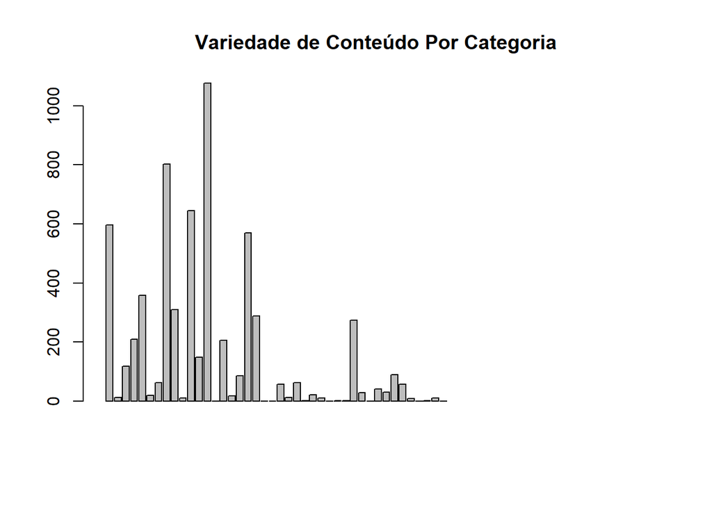

```r
barplot(resultado$quantidade, main = "Variedade de Conteúdo Por Categoria", cex.names = 0.5, xlim = c(0,80))
```

**3. Tempo de Conteúdo Disponível**  
Um dos aspectos que o usuário de streaming buscam correspondem ao quanto de conteúdo ele tem para aproveitar. Claro que podemos considerar apenas a quantidade de produto disponível sendo 4264 filmes e 1969 Programas de Tv. Mas existe outro ponto a ser discutido, o tempo que levará para um usuário consiga terminar todo o catálogo. Duas totalidades de tempos será buscada, tempo disponível de filmes e tempo disponíveis de programas de tv. Irei Criar duas funções, a função abaixo para obter o tempo em horas de filmes.

```r
Tempo_Horas_Filmes <- function(dataset){
  aux <- as.numeric(str_trim(str_remove_all(subset(dataset[,"duration"], dataset$type == "Movie"), "[a-z]")))
  horas <- sum(aux)/60
  return(horas)
}
```

que resulta em 7041.7 horas.

Agora, a função para obter o tempo em horas dos programas de tv. Para os programas de tv a duração informada refere-se ao número de temporadas, sem considerar numero de episódios ou duração deles. Por isso, o valor usado para determinar o tempo será o mínimo que a plataforma programas costumam a oferecer, numero de 8 episódios e 20 min de duração.

```r
Tempo_Horas_TvShow <- function(dataset){
  aux <- as.numeric(str_trim(str_remove_all(subset(dataset[,"duration"], dataset$type == "TV Show"), "[:upper:][:lower:]*")))
  horas_min <- sum(aux*8*20)/60
  return(horas_min)
}
```

que resulta em 9344 horas.  
Possuindo esses dois valores, somados dão 683 dias corridos de conteúdo para ser visto.

Para classificar esse aspecto, irei considerar os dois aspectos anteriores. A quantidade de tempo de conteúdo disponível é ótimo ainda mais se considerarmos que mais e mais conteúdos são incluídos no catálogo. Porém, como visto que a maioria dos filmes se concentram em algumas poucas categorias, e o público deve se atentar as suas preferências, o tempo de duração disponível decai. Fazendo assim decair também a classificação desse aspecto de ótimo para **Bom**.

**4. Variedade de Temas com base na descrição**  
A plataforma netflix possui uma ferramenta de busca, no qual o usuário digita uma palavra e aparecem os conteúdos que a correspondem, seja pelo título ou sinopse do conteúdo. Sabendo que geralmente as sinopses possuem uma palavra-chave que correspondem ao tema do conteúdo, irei explorar essas sinopses, a fim de verificar a variedade de temas disponíveis.

Utilizando do código abaixo para gerar uma nuvem de palavras com os temas.

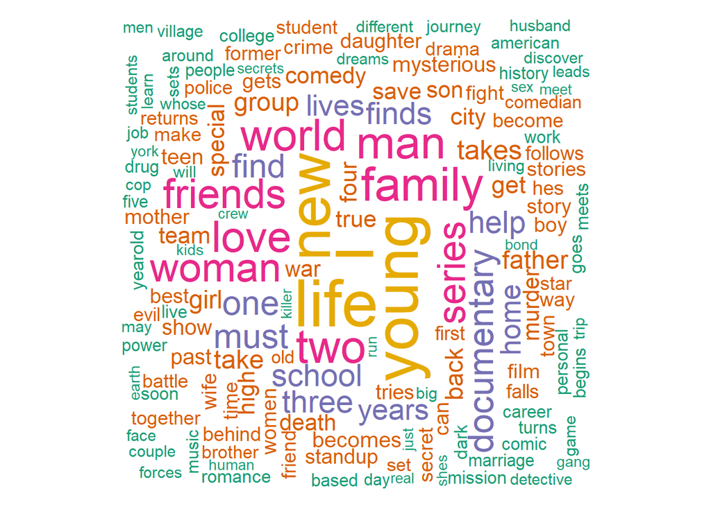

```r
texto <- paste(netflix$description, collapse = " ")
#Convertendo para o Formato Corpus
VS  <- VectorSource(texto)
corpus <- Corpus(VS)

#Formatando o Texto
corpus <- tm_map(corpus, content_transformer(tolower))
corpus <- tm_map(corpus, removePunctuation)
corpus <- tm_map(corpus, stripWhitespace)
corpus <- tm_map(corpus, removeNumbers)
corpus <- tm_map(corpus, removeWords, stopwords('english'))
#Gerando Nuvem
wordcloud(corpus, min.freq = 3, max.words = 200, random.order = FALSE, rot.per = 0.20
          ,colors = brewer.pal(6, "Dark2"))
```

**5. Procura de Filmes/Tv Show por Elenco**  
Além de busca por título e temas, a Netflix permite fazer a busca por atores/atrizes. É comum, o usuário querer assistir conteúdos no qual seu ator/atriz favorito participou, por isso busco nesses aspectos verificar não só a quantidade de atores presentes por todo catálogo, mas também os conteúdos que os mesmos participaram.

Igualmente as categorias, um filme possui mais de um ator/atriz. Só que diferentemente da categoria, ficaria inviável separar em novas colunas já que existe elenco com 49. Então, criei a função abaixo para fazer essa separação e trazer em um vetor.

```r
ver_Elenco <- function(dataset){
  nome_elenco <- c()

  #Removendo NA's
  dataset <- dataset[-which(is.na(dataset))]
  #Removendo NA's

  for(i in 1: length(dataset)){
    aux <- c(0)
    for(j in 1 : str_length(dataset[i])){
      if(substr(dataset[i],j,j) == ","){
        aux  <- c(aux, j)
      }
    }
    aux <- c(aux,str_length(dataset[i]) + 1)
    for(h in 1 : (length(aux) - 1)){
      nome_elenco <- c(nome_elenco,substr(dataset[i], aux[h]+1, aux[h+1]-1))
    }
  }

  return(nome_elenco)
}
Elenco <- ver_Elenco(netflix$cast)
```

Após isso, removo os espaços em brancos desnecessários e transformo o vetor em um dataframe para melhor manipula-lo.

```r
Elenco <- str_trim(Elenco)
Elenco <- data.frame(Elenco)
```

Agora, finalmente, utilizo do código abaixo para obter a frequência dos atores e gerar um gráfico.

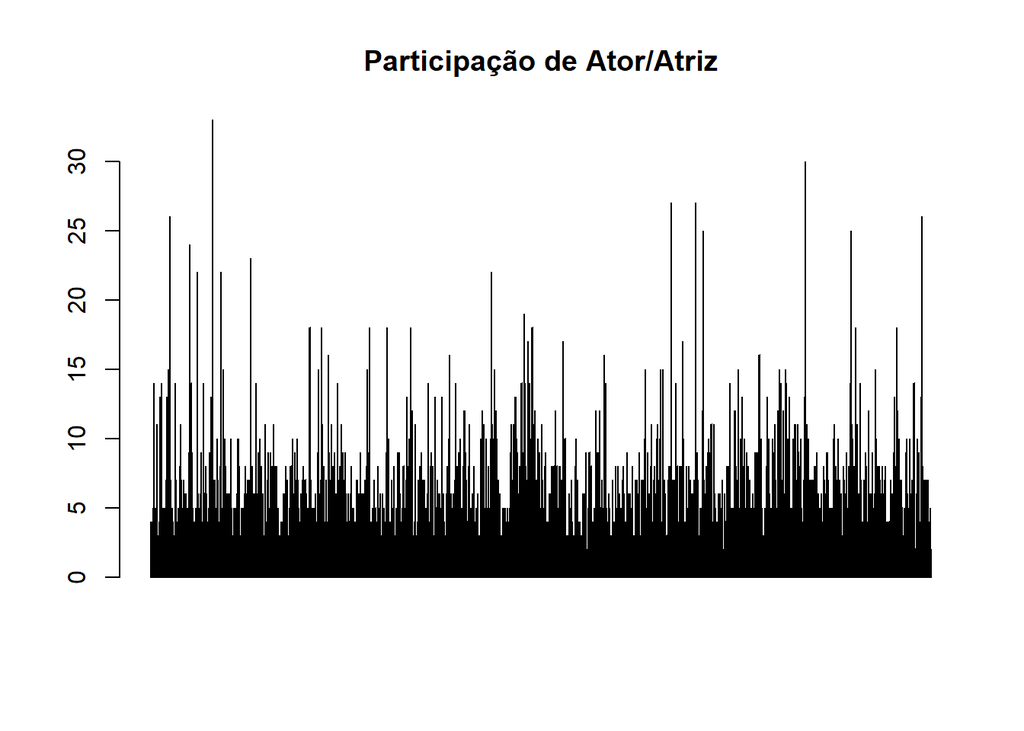

```r
Elenco <- Elenco %>% group_by(Elenco) %>% summarise(frequencia = n())
barplot(Elenco$frequencia, main = "Participação de Ator/Atriz", cex.names = 0.5)
```

O gráfico está apresentando a frequência de 27405 Atores/Atrizes. Para classificar este aspecto, analiso que a grande concentração se encontra abaixo de 10 filmes/Tv Show’s. Porém, os picos apresentados no gráfico referisse aos atores/atrizes “estrelas”, e que mesmo pequenas participações chegam a ser consideradas, e os que ficam na base podem representar atores/atrizes secundários ou não tão famosos. Desse modo, classifico esse aspecto em **Bom**, já que, mesmo com esses pontos levantados ainda existem um baixo nível de participação geral, ainda mais se considerarmos todos os “estrelas” existentes.

## Conclusões

Para finalizar, trago esta tabela no qual irá medir a classificação da plataforma de streaming netflix, baseada na classificação dos aspectos antes verificados.

[figure not shown]

Observando o total de pontos acumulados, podemos agora definir a classificação geral Netflix com base na escala a seguir.

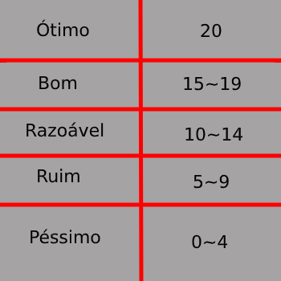

Logo, a plataforma de streaming Netflix, cobre alguns dos interesses dos usuários de maneira **Razoável**. Claro que, este trabalho pode ser continuado e melhor classificado. Para isto, serão necessários novos dados a serem disponibilizados e alguns outros aspectos a serem verificados.